# Predicting Credit Risk

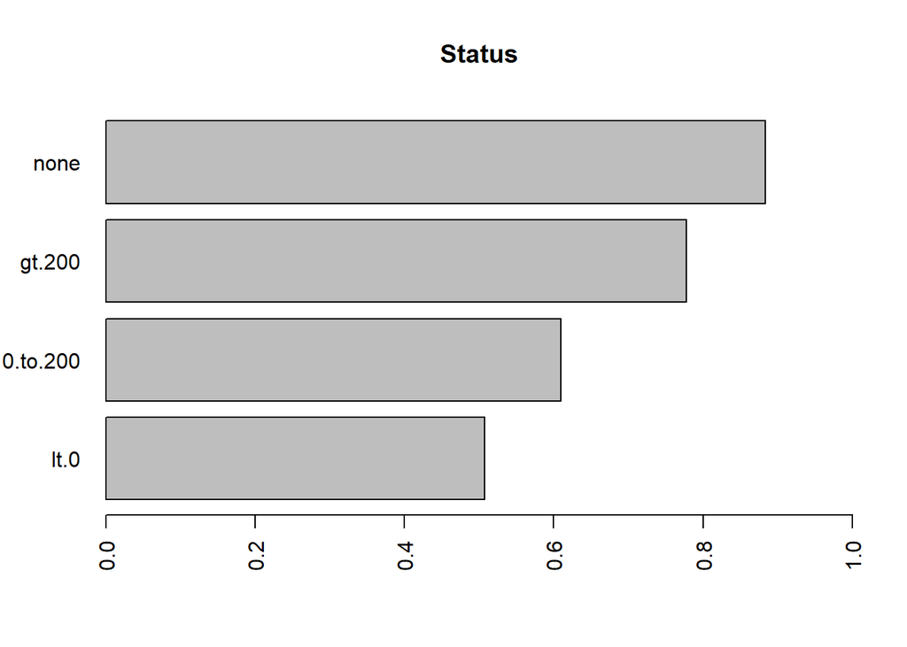

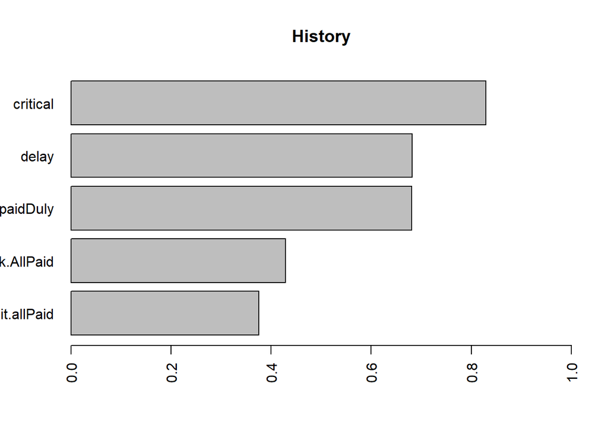

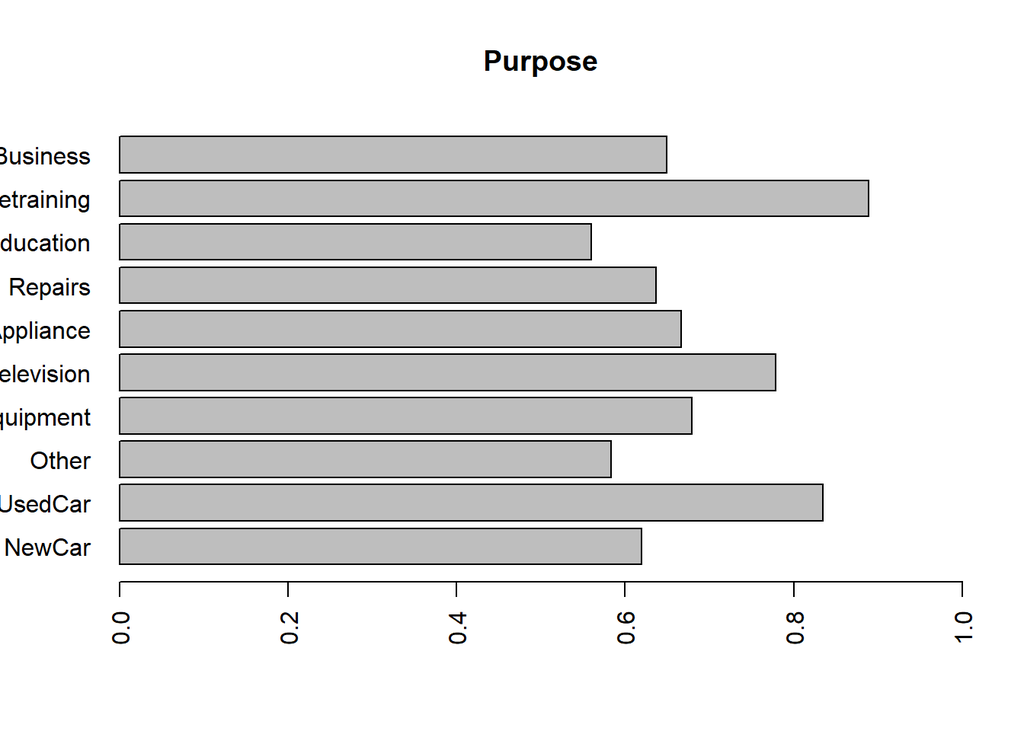

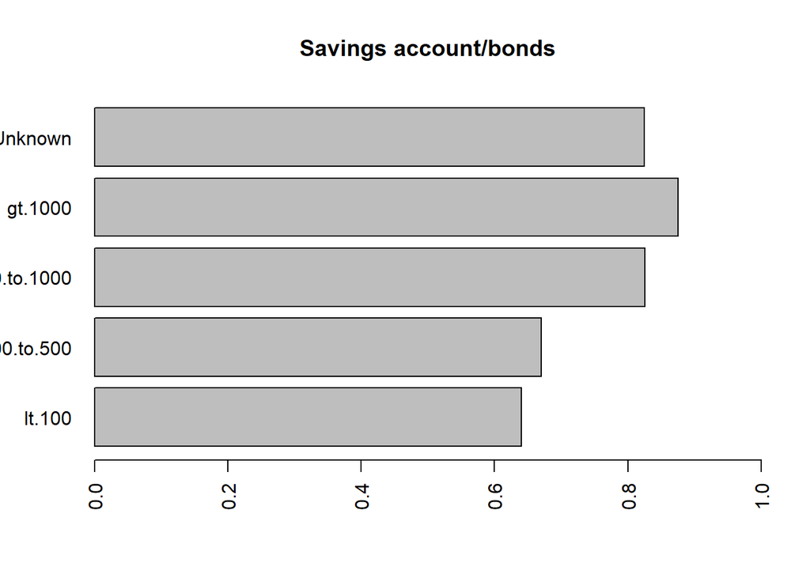

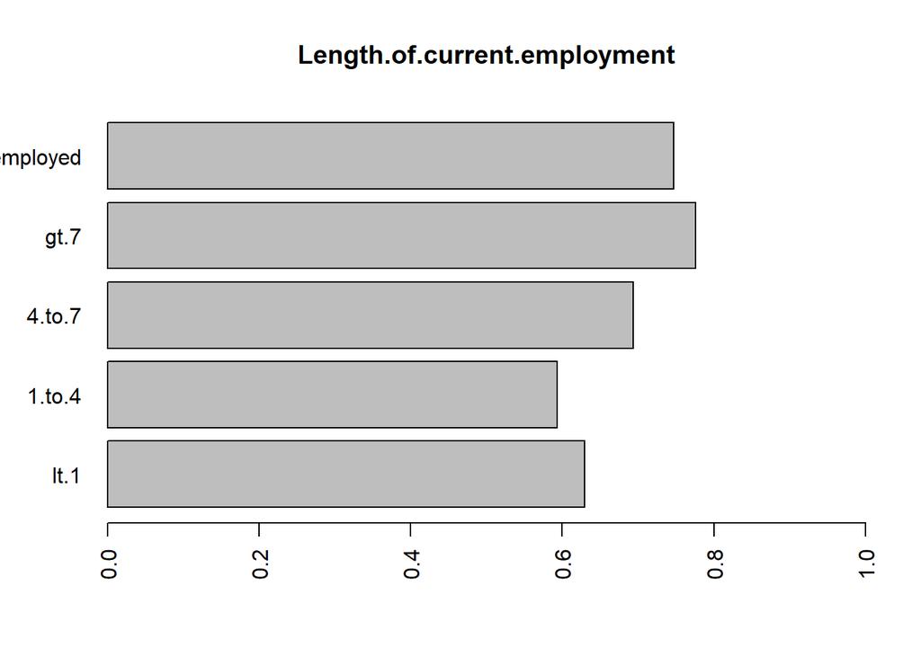

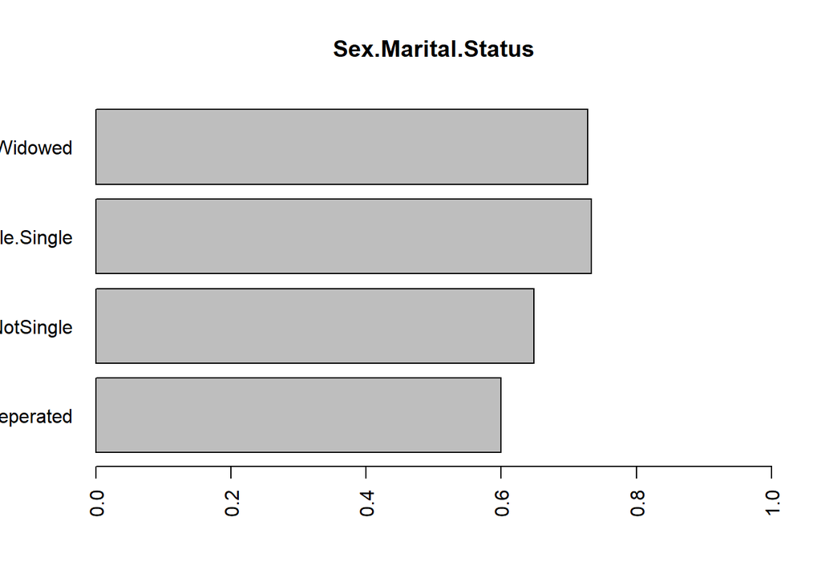

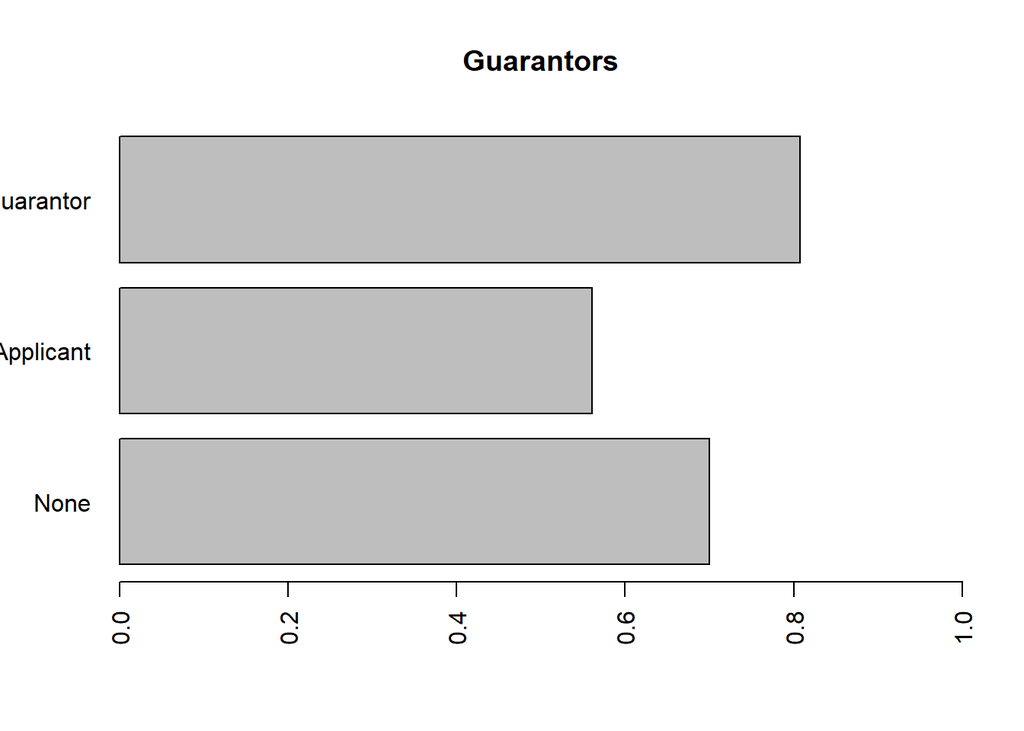

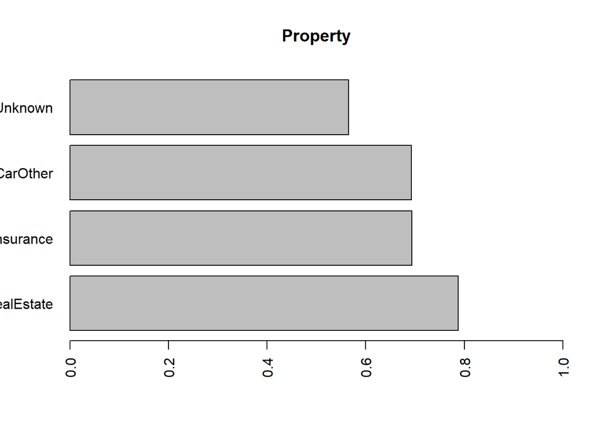

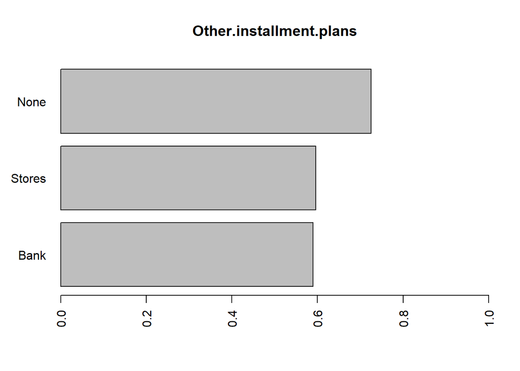

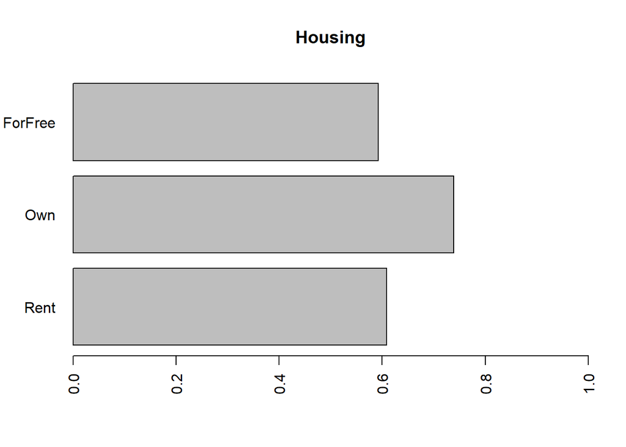

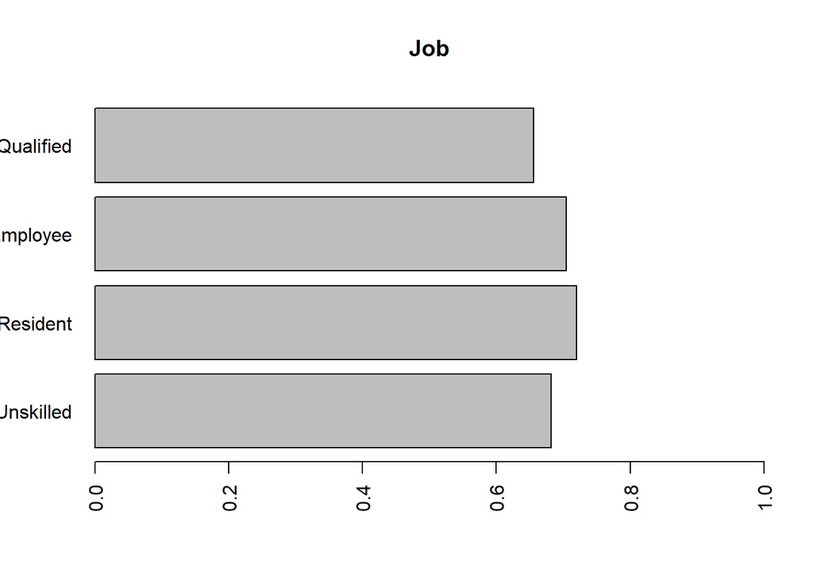

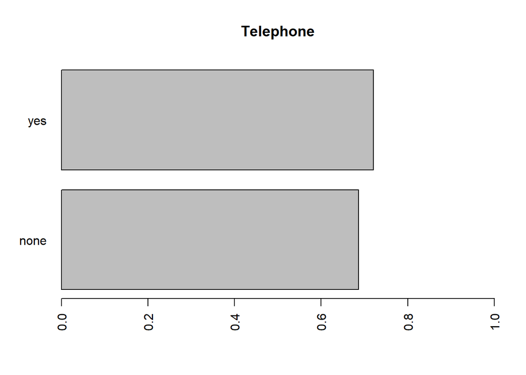

[1 more figures not shown]

[output not shown]

[output cut: 37 more lines]

[output not shown]

```r
var.expl.quali<-names(var.factor[-length(var.factor)])
mapply(don[,var.expl.quali],FUN=function(xx,name){
  tmp<-table(xx,don$Creditability)
  tmp<-tmp/rowSums(tmp)
  barplot(tmp[,"good"],main=name,horiz = TRUE,las=2,xlim=c(0,1))
},name=var.expl.quali)
```

Par exemple, on voit que la proportion de bons payeurs est sensiblement la même que le client prenne la modalité thisBank.AllPaid ou noCredit.allPaid de la variable History. Ces deux modalités étant rares (cf Section 4.1.2), on pourra les fusionner si cela est nécessaire pour les méthodes d’analyse employées.

### 4.2.2 Lien entre variables explicatives

Des liaisons trop fortes entre variables explicatives peuvent conduire à de grande instabilité dans les modèles. L’analyse des liaisons entre variables explicatives permettra de détecter les couples de variables les plus liées.

#### 4.2.2.1 Variables quantitatives

On détermine les valeurs des coefficients de corrélation linéaire et de Spearman entre les variables quantitatives.

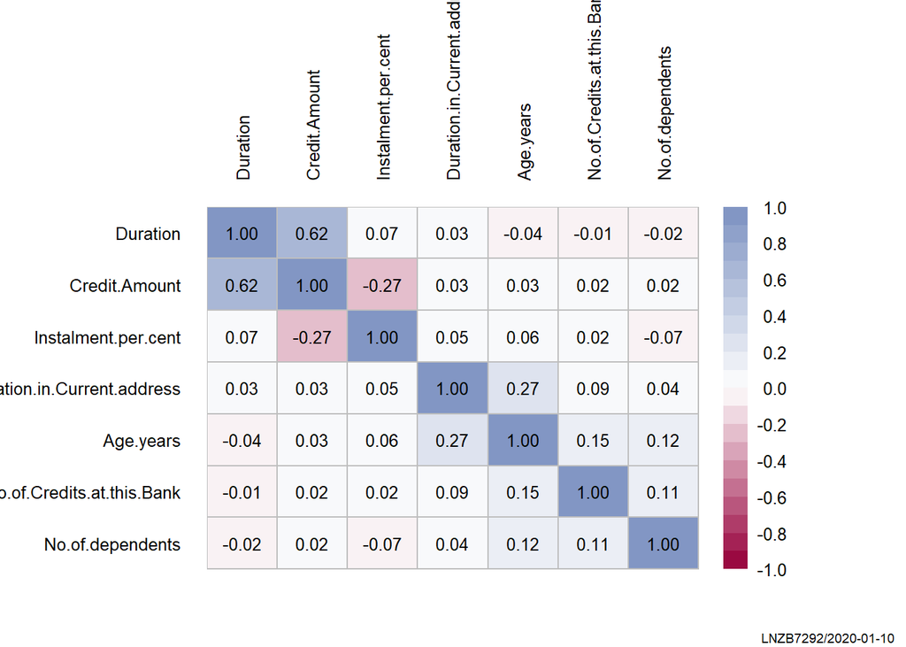

```r
matcor<-cor(don[,var.numeric])
PlotCorr(matcor)
text(x=rep(1:ncol(matcor),ncol(matcor)), y=rep(1:ncol(matcor),each=ncol(matcor)),
     label=sprintf("%0.2f", matcor[,ncol(matcor):1]), cex=0.8, xpd=TRUE)
```

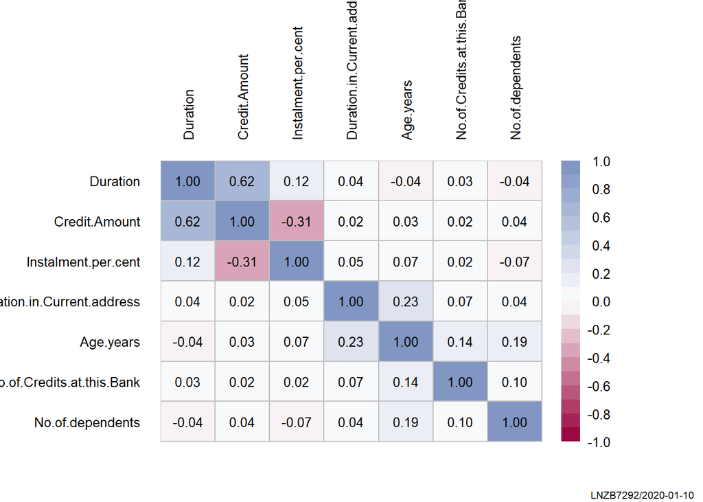

```r
matcor<-cor(don[,var.numeric],method = "spearman")
PlotCorr(matcor)
text(x=rep(1:ncol(matcor),ncol(matcor)), y=rep(1:ncol(matcor),each=ncol(matcor)),
     label=sprintf("%0.2f", matcor[,ncol(matcor):1]), cex=0.8, xpd=TRUE)
```

Les coefficients de corrélation et de Spearman sont plutôt proches pour les différents couples de variables. Dans le cas contraire, on aurait essayé de comprendre cette différence en analysant la forme des nuages de points pour les couples. Notons que l’on aurait pu également comparer le coefficient de corrélation au carré et le η2

On constate que les liaisons ne sont pas très fortes, on ne s’attend donc pas à des problèmes de colinéarité entre ces variables.

#### 4.2.2.2 Variables quantitatives et qualitatives

De même, on calcule le η2 entre les variables quantitatives et les variables qualitatives.

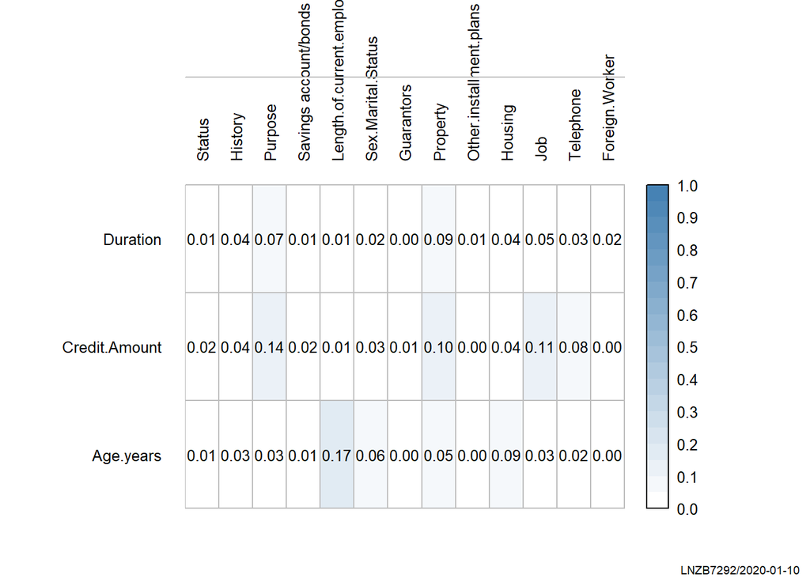

```r
# creation d'une matrice vide avec en ligne les variables quantitatives et en colonne les variables qualitatives
mateta2<-matrix(NA,13,3)
rownames(mateta2)<-c("Status", "History", "Purpose", "Savings account/bonds", "Length.of.current.employment",
"Sex.Marital.Status", "Guarantors", "Property", "Other.installment.plans",
"Housing", "Job", "Telephone", "Foreign.Worker")
colnames(mateta2)<-c("Duration", "Credit.Amount", "Age.years")

# calcul des diff?rents eta carr?
for(ii in seq(nrow(mateta2))){
  for(jj in seq(ncol(mateta2))){
    mateta2[ii,jj]<-eta2(don[,colnames(mateta2)[jj]],
                         don[,rownames(mateta2)[ii]])
  }
}

# affichage
PlotCorr(mateta2,
         cols = colorRampPalette(c("white", "steelblue"), space = "rgb")(20),
         breaks=seq(0, 1, length=21),
         args.colorlegend = list(labels=sprintf("%.1f", seq(0, 1, length = 11)), frame=TRUE))
text(x=rep(1:nrow(mateta2),ncol(mateta2)),
     y=rep(1:ncol(mateta2),each=nrow(mateta2)),
     label=sprintf("%0.2f", mateta2[,ncol(mateta2):1]),
     cex=0.8,
     xpd=TRUE)
```

Les liaisons entre variables explicatives quantitatives et qualitatives semblent plutôt ténues.

#### 4.2.2.3 Variables qualitatives

De la même façon, on détermine les V de Cramer entre les variables explicatives qualitatives.

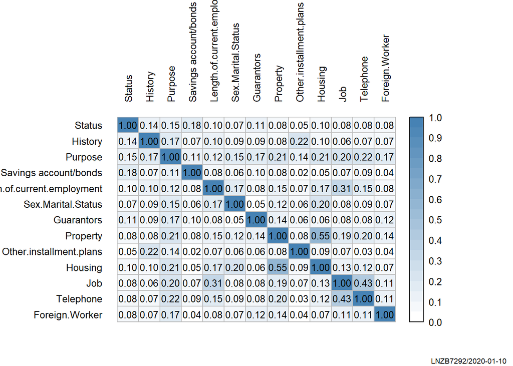

```r
matcram<-PairApply(don[,var.expl.quali], CramerV, symmetric = TRUE)
PlotCorr(matcram,
         cols = colorRampPalette(c("white", "steelblue"), space = "rgb")(20),
         breaks=seq(0, 1, length=21),
         args.colorlegend = list(labels=sprintf("%.1f", seq(0, 1, length = 11)), frame=TRUE))
text(x=rep(1:ncol(matcram),ncol(matcram)), y=rep(1:ncol(matcram),each=ncol(matcram)),
     label=sprintf("%0.2f", matcram[,ncol(matcram):1]), cex=0.8, xpd=TRUE)
```

```r
cont.table<-table(don[,c("Housing","Property")])
cont.table
```

```
##          Property
## Housing   RealEstate Insurance CarOther Unknown
##   Rent            55        46       60      18
##   Own            226       184      271      32
##   ForFree          1         2        1     104
```

```r
chisq <- chisq.test(cont.table)
chisq
```

```
##
##  Pearson's Chi-squared test
##
## data:  cont.table
## X-squared = 612.02, df = 6, p-value < 2.2e-16
```

```r
chisq$p.value
```

```
## [1] 5.96017e-129
```

```r
chisq$df
```

[output not shown]

Clairement, il existe une association très forte, entre les modalités ForFree de la variable Housing et Unknown de la variable Property. Pour aller plus loin, on peut effectuer une analyse factorielle des correspondances (AFC) entre les deux variables.

```r
don1<-don[,c(12,15)]
library("gplots")

library("FactoMineR")
library("factoextra")
#res.afc<-CA(don1)
```

```r
library("FactoMineR")
library("factoextra")
data(housetasks)
chisq <- chisq.test (housetasks)
chisq
chisq$p.value
library("gplots")
# 1. convertir les données en tant que table
dt <- as.table(as.matrix (housetasks))
# 2. Graphique
balloonplot(t (dt), main = "housetasks", xlab = "", ylab = "",
            label = FALSE, show.margins = FALSE)

#test AFC
housetasks$Wife

cont.table2<-table(housetasks[,c("Husband","Wife")])
cont.table2
chisq <- chisq.test(cont.table2)
chisq
chisq$p.value
chisq$df
#res.ca2 <- CA (cont.table2)


res.ca <- CA (housetasks)
print(res.ca)
```

[output not shown]

```r
# initialisation de la graine du g?n?rateur al?atoire (pour reproductibilit? des r?sultats)
set.seed(0)

# discr?tisation en 4 classes des variables quantitatives (quand elles prennent un nombre de valeurs sup?rieure ? 10)
don.cat<-don
for(i in which(sapply(don,is.numeric))){
  if(length(table(don.cat[[i]]))>10){
    breaks<-c(-Inf,quantile(don.cat[[i]],
                            na.rm=T)[-1])
    don.cat[[i]]<-cut(don.cat[[i]],
                      breaks=breaks,labels=F);
  }
  don.cat[[i]]<-as.factor(don.cat[[i]])
}

str(don.cat)
```

```
## 'data.frame':    1000 obs. of  21 variables:
##  $ Status                      : Factor w/ 4 levels "lt.0","0.to.200",..: 1 2 4 1 1 4 4 2 4 2 ...
##  $ Duration                    : Factor w/ 4 levels "1","2","3","4": 1 4 1 4 3 4 3 4 1 4 ...
##  $ History                     : Factor w/ 5 levels "noCredit.allPaid",..: 5 3 5 3 4 3 3 3 3 5 ...
##  $ Purpose                     : Factor w/ 10 levels "NewCar","UsedCar",..: 5 5 8 4 1 8 4 2 5 1 ...
##  $ Credit.Amount               : Factor w/ 4 levels "1","2","3","4": 1 4 2 4 4 4 3 4 3 4 ...
##  $ Savings account/bonds       : Factor w/ 5 levels "lt.100","100.to.500",..: 5 1 1 1 1 5 3 1 4 1 ...
##  $ Length.of.current.employment: Factor w/ 5 levels "lt.1","1.to.4",..: 5 3 4 4 3 3 5 3 4 1 ...
##  $ Instalment.per.cent         : Factor w/ 4 levels "1","2","3","4": 4 2 2 2 3 2 3 2 2 4 ...
##  $ Sex.Marital.Status          : Factor w/ 4 levels "Male.Divorced.Seperated",..: 3 2 3 3 3 3 3 3 1 4 ...
##  $ Guarantors                  : Factor w/ 3 levels "None","CoApplicant",..: 1 1 1 3 1 1 1 1 1 1 ...
##  $ Duration.in.Current.address : Factor w/ 4 levels "1","2","3","4": 4 2 3 4 4 4 4 2 4 2 ...
##  $ Property                    : Factor w/ 4 levels "RealEstate","Insurance",..: 1 1 1 2 4 4 2 3 1 3 ...
##  $ Age.years                   : Factor w/ 4 levels "1","2","3","4": 4 1 4 4 4 3 4 3 4 2 ...
##  $ Other.installment.plans     : Factor w/ 3 levels "Bank","Stores",..: 3 3 3 3 3 3 3 3 3 3 ...
##  $ Housing                     : Factor w/ 3 levels "Rent","Own","ForFree": 2 2 2 3 3 3 2 1 2 2 ...
##  $ No.of.Credits.at.this.Bank  : Factor w/ 4 levels "1","2","3","4": 2 1 1 1 2 1 1 1 1 2 ...
##  $ Job                         : Factor w/ 4 levels "UnemployedUnskilled",..: 3 3 2 3 3 2 3 4 2 4 ...
##  $ No.of.dependents            : Factor w/ 2 levels "1","2": 1 1 2 2 2 2 1 1 1 1 ...
##  $ Telephone                   : Factor w/ 2 levels "none","yes": 2 1 1 1 1 2 1 2 1 1 ...
##  $ Foreign.Worker              : Factor w/ 2 levels "yes","no": 1 1 1 1 1 1 1 1 1 1 ...
##  $ Creditability               : Factor w/ 2 levels "good","bad": 1 2 1 1 2 1 1 1 1 2 ...
```

On realise l’ACM en mettant la variable Creditability en variable illustrative. On gere les modalités rares (fréquence relative <5%) en effectuant de la ventilation

```r
res.mca<-MCA(don.cat,graph=FALSE,quali.sup=ncol(don.cat),level.ventil = 0.05)
```

On effectue l’ACM en représentant ici le graphe des individus, celui des modalités, et celui des variables On affiche les graphiques relatifs au premier plan

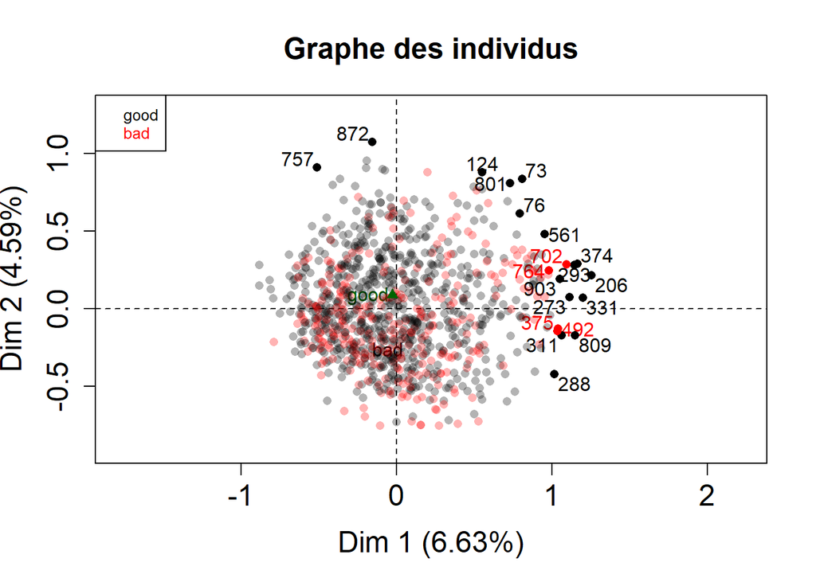

```r
#individus (aux plus fortes contributions)
plot.MCA(res.mca, choix="ind",
         habillage = as.numeric(ncol(don.cat)),
         invisible="var",
         select="contrib 20",
         title="Graphe des individus",
         cex.lab=1.5,
         cex.main=1.5,
         cex.axis=1.5)
```

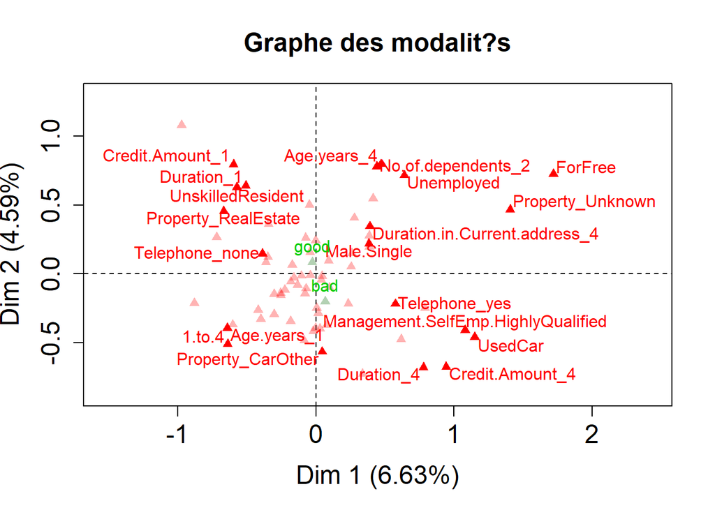

```r
#modalit?s (aux plus fortes contributions)
plot.MCA(res.mca, choix="ind",
         label = "var",
         invisible="ind",
         cex.lab=1.5,
         cex.main=1.5,
         cex.axis=1.5,
         col.lab = TRUE,
         title='Graphe des modalit?s',
         selectMod = "contrib 20")
# on ajoute les modalit?s de la variable illustrative
text(res.mca$quali.sup$coord[,1:2],labels = rownames(res.mca$quali.sup$coord),pos = 3,col=3)
```

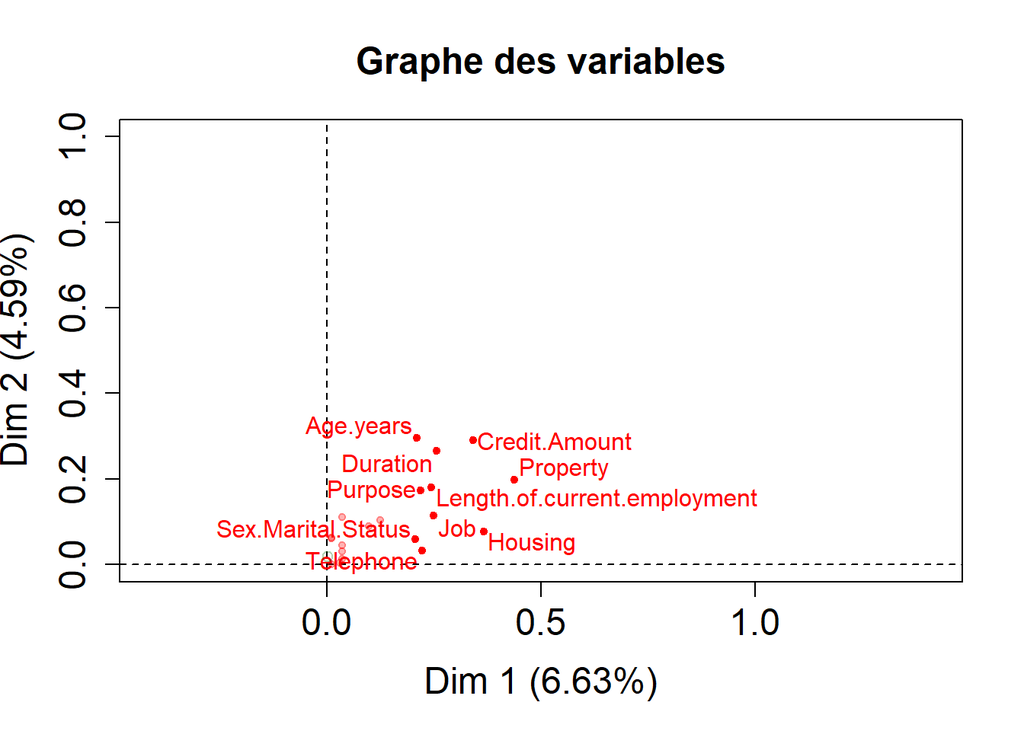

```r
#variables (aux plus fortes coordonn?es)
plot(res.mca, choix="var",
     select="coord 10",
     title="Graphe des variables",
     cex.lab=1.5,
     cex.main=1.5,
     cex.axis=1.5)
```

# Classification

On complete cette analyse par une CAH sur les composantes de l’ACM. Pour cela, on retient les premières composantes telles que l’inertie cumulée atteigne 80% (i.e. les 32 premieres).

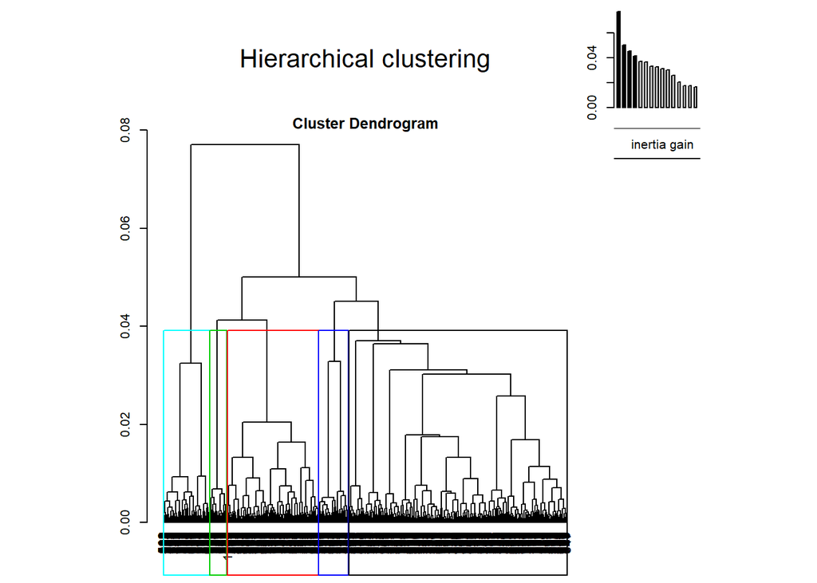

```r
set.seed(0)

# Choix du nombre de composantes
ncp<-which(res.mca$eig[,3]>80)[1]

# On effectue l'ACM en conservant les 32 premi?res dimensions
res.mca<-MCA(don.cat,graph=FALSE,quali.sup=ncol(don.cat),level.ventil = 0.05,ncp=ncp)

# On effectue la CAH (avec 5 classes d'apr?s le diagramme des gains d'inertie)
res.cah<-HCPC(res.mca,nb.clust=5,graph=FALSE, description = FALSE)

# On affiche le dendogramme
plot(res.cah, choice="tree")
```

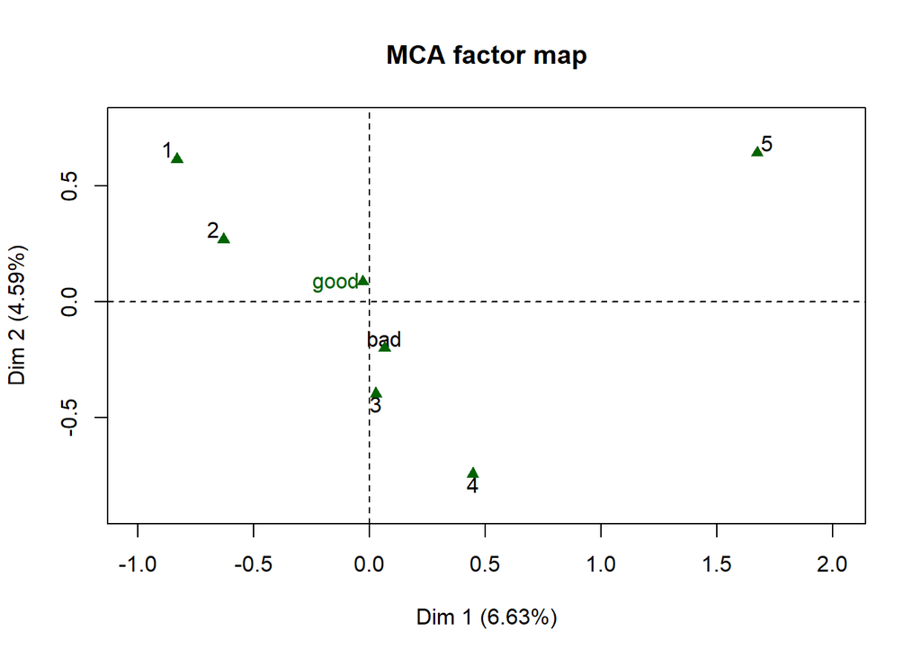

```r
# On repr?sente les classes sur le graphe de l'ACM
set.seed(0)
res.mca.clust<-MCA(res.cah$data.clust,
                   graph=FALSE,
                   quali.sup=c(ncol(don.cat),ncol(res.cah$data.clust)),
                   level.ventil = 0.05)
plot.MCA(res.mca.clust,
         habillage = ncol(res.cah$data.clust),
         choix="ind",invisible=c("ind","var"))
```

```r
#Investigate(res.mca,nclust=5,ncp=32)
catdes(res.cah$data.clust,num.var = ncol(res.cah$data.clust))
```

```
##
## Link between the cluster variable and the categorical variables (chi-square test)
## =================================================================================
##                                    p.value df
## Sex.Marital.Status           4.941464e-235 12
## Property                     7.126508e-186 12
## Housing                      9.703269e-170  8
## Guarantors                   4.662649e-128  4
## Foreign.Worker                3.106725e-84  4
## Credit.Amount                 8.691296e-80 12
## Duration                      1.345903e-68 12
## Purpose                       2.088595e-32 20
## Job                           1.709630e-25  8
## Telephone                     2.779286e-20  4
## Age.years                     4.167859e-18 12
## Length.of.current.employment  1.300843e-17 16
## Duration.in.Current.address   1.201190e-15 12
## History                       2.065408e-11  8
## Status                        3.779920e-06 12
## Savings.account/bonds         1.489489e-05 12
## Creditability                 7.042270e-05  4
## No.of.dependents              9.120734e-05  4
## No.of.Credits.at.this.Bank    5.743420e-04  4
## Instalment.per.cent           1.201095e-03 12
## Other.installment.plans       6.182264e-03  4
##
## Description of each cluster by the categories
## =============================================
## $`1`
##                                                              Cla/Mod
## Guarantors=Guarantors_Guarantor                           96.4285714
## Foreign.Worker=Foreign.Worker_no                          97.2972973
## Property=Property_RealEstate                              16.6666667
## Job=UnskilledResident                                     15.0485437
## Telephone=Telephone_none                                  10.9060403
## Duration=Duration_1                                       12.5348189
## Creditability=good                                        10.1428571
## Purpose=NewCar                                            12.5506073
## Savings.account/bonds=Savings account/bonds_lt.100         9.8101266
## No.of.dependents=No.of.dependents_2                       12.9032258
```

[output cut: 925 more lines]

```
## Sex.Marital.Status=Female.NotSingle                        -3.475315
## Duration=Duration_1                                        -3.532160
## Length.of.current.employment=1.to.4                        -3.635546
## Creditability=good                                         -3.679524
## Sex.Marital.Status=Male.Married.Widowed                    -4.056266
## Purpose=Radio.Television                                   -4.074171
## Housing=Rent                                               -4.143752
## Telephone=Telephone_none                                   -4.507350
## Job=UnskilledResident                                      -4.529205
## Duration.in.Current.address=Duration.in.Current.address_2  -5.335396
## Age.years=Age.years_1                                      -5.453728
## Property=Property_Insurance                                -7.598704
## Property=Property_RealEstate                               -8.663004
## Property=Property_CarOther                                 -9.688967
## Housing=Own                                               -15.449727
```

## 5.1 Transformations

### 5.1.1 Variables quantitatives

Une des transformation les plus couramment appliquée aux variables quantitatives est la discrétisation. Celle-ci permettra notamment d’harmoniser la nature des variables. Par ailleurs, il arrive fréquemment que les modèles statistiques reposent sur une hypothèse de normalité des variables. Quand cette hypothèse n’est pas vérifiée, on peut souhaiter effectuer une transformation des variables pour s’y ramener. De même, quand la relation entre une variable explicative continue et une variables réponse n’est pas linéaire, on pourra préférer découper cette variable explicative en classes, en particulier quand le lien n’est pas monotone (voir Section 4.2.1.1).

#### 5.1.1.1 Découpage en classes

Comme pour la détermination des classes d’un histogramme, le découpage en classes d’une variable quantitatives peut être effectué de différentes façons. En particulier, on peut faire un découpage ``métier’’, en choisissant des classes classiques pour le critère mesuré, ou par des approches plus statistiques, notamment selon les quantiles. Dans le cas d’un problème de classification supervisée, il sera préférable d’utiliser l’algorithme MDLPC de Fayyad et Irani (Fayyad and Irani (1993)), disponible dans le package discretization.

```r
library(discretization)
res.mdlp<-mdlp(don[,c("Duration", "Credit.Amount", "Age.years","Creditability")])
str(res.mdlp$Disc.data)
```

```
## 'data.frame':    1000 obs. of  4 variables:
##  $ Duration     : int  1 2 1 2 2 2 2 2 1 2 ...
##  $ Credit.Amount: int  1 2 1 2 2 2 1 2 1 2 ...
##  $ Age.years    : int  1 1 1 1 1 1 1 1 1 1 ...
##  $ Creditability: Factor w/ 2 levels "good","bad": 1 2 1 1 2 1 1 1 1 2 ...
```

```r
sapply(c("Duration", "Credit.Amount"),
       FUN=function(var,res.mdlp){
         chisq.test(res.mdlp$Disc.data[,var],res.mdlp$Disc.data$Creditability)$p.value
       },
       res.mdlp=res.mdlp)
```

```
##      Duration Credit.Amount
##  2.923046e-08  3.171735e-07
```

```r
don$Duration.cat<-res.mdlp$Disc.data$Duration
don$Credit.Amount.cat<-res.mdlp$Disc.data$Credit.Amount
```

## Linearite

```r
don$Age.years.cat<-cut(don$Age.years,breaks = c(0,24,35,100))
```

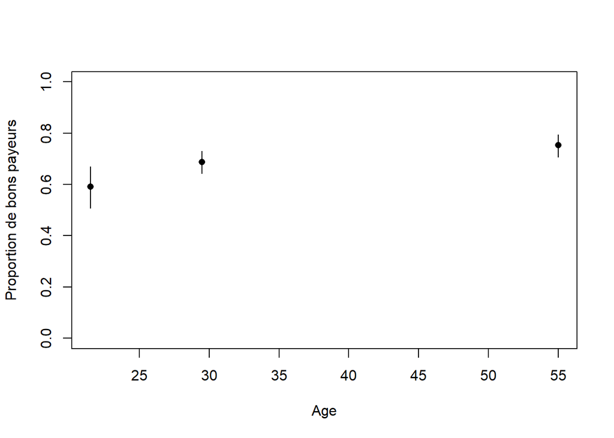

```r
cont.table<-table(don$Age.years.cat,don$Creditability)
prof.lignes<-prop.table(cont.table,1)
res.binom.test<-mapply(cont.table[,1],
                       FUN=binom.test,
                       n=rowSums(cont.table),
                       SIMPLIFY = FALSE)
ci<-sapply(res.binom.test,"[[","conf.int")
abscisses<-c((19+24)/2,(24+35)/2,(35+75)/2)

plot(abscisses,
     prof.lignes[,1],
     pch=16,
     col=1,
     xlab="Age",
     ylab="Proportion de bons payeurs",
     ylim=c(0,1))

for(ii in 1:length(abscisses)){
  segments(x0=abscisses[ii],
           y0=ci[1,ii],
           x1=abscisses[ii],
           y1=ci[2,ii],
           col=1)
}
```

```r
chisq.test(don$Age.years.cat, don$Creditability)$p.value
```

```
## [1] 0.0008298968
```

```r
don$Credit.Amount.log<-log(don$Credit.Amount)
```

```r
par(mfrow=c(1,2))
qqPlot(don$Credit.Amount)
```

```
## [1] 916  96
```

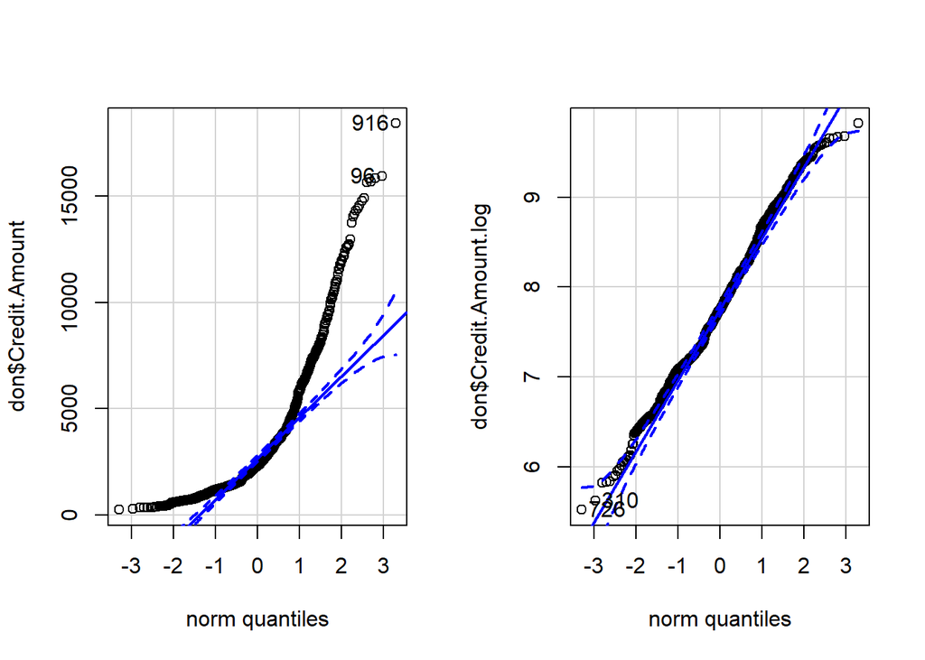

```
## [1] 726 310
```

```r
qqPlot(don$Credit.Amount.log)
```

```r
#coefficient d'asymetrie
coefasym<-function(x){
  m <- mean(x)
  mu2 <- mean( (x-m)^2 )
  mu3 <- mean( (x-m)^3 )
  sigma <- sqrt(mu2)
  gamma1 <- mu3/sigma^3
  return(gamma1)
}
```

```r
coefasym(don$Credit.Amount)
```

```
## [1] 1.946702
```

```r
coefasym(don$Credit.Amount.log)
```

```
## [1] 0.1290919
```

on cree une fonction qui prend en entrée une grille pour le paramètre lambda,ainsi que la variable a transformer et qui,pour chaque valeur de lambda,renvoie le coefficient de correlation entre les quantiles

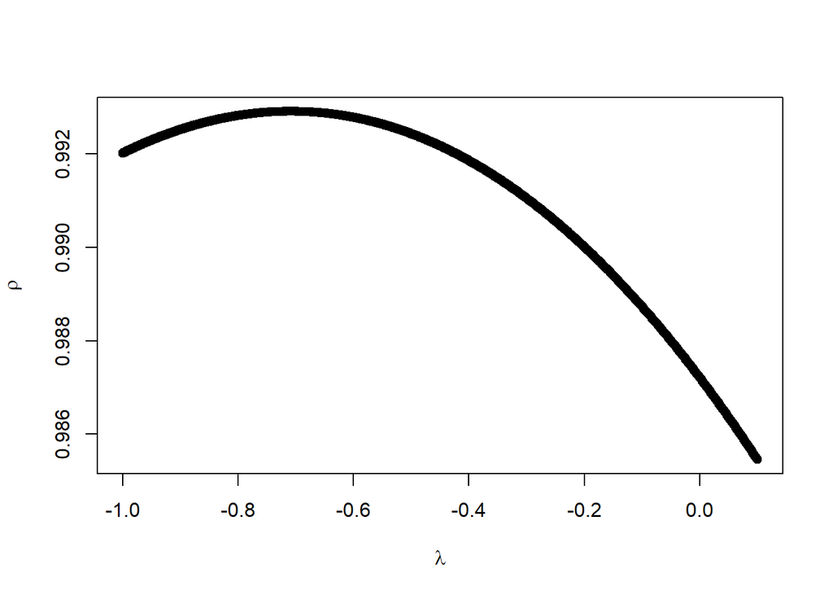

```r
myBoxCox<-function(lambda.grid,var){
  res.cor<-rep(NA,length(lambda.grid))
  comp<-0
  probs<-seq(1/length(var),(length(var)-1)/length(var),1/length(var))
  quantilenormale<-qnorm(probs)
  for (lambda in lambda.grid){
    #on incremente un compteur
    comp<-comp+1
    #on effectue la transformation pour le lambda courant
    var.boxcox<-BoxCox(var,lambda = lambda)
    #on calcule le coefficient de corr?lation entre les quantiles
    # de la variable transform?e et ceux d'une loi normale
    res.cor[comp]<-cor(quantile(var.boxcox,probs = probs),
                       quantilenormale)
  }
  return(res.cor)
}


# on d?finit une grille et on calcule la correlation entre les quantiles
# en fonction du parametre de la grille
lambda.grid<-seq(-1,0.1,1/1000)
res.cor<-myBoxCox(lambda.grid=lambda.grid,var=don$Age.years)
# on affiche l'?volution du coefficient de corr?lation en fonction de lambda
plot(lambda.grid,res.cor,xlab=expression(lambda),ylab=expression(rho))
```

```r
#on identifie la valeur de lambda qui maximise la correlation
lambda.grid[which.max(res.cor)]
```

```
## [1] -0.709
```

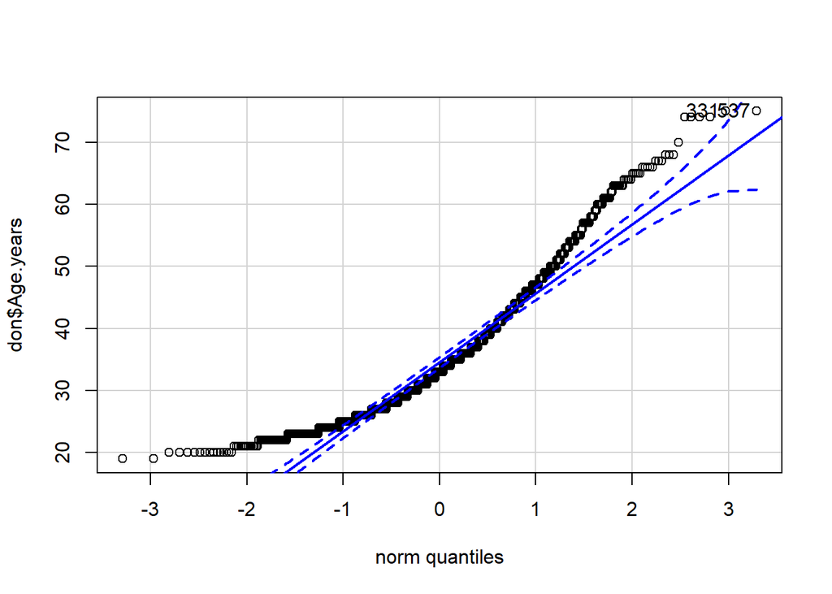

```
## [1] 331 537
```

```r
#on effectue donc la transformation pour lambda = -0.709
don$Age.years.norm<-BoxCox(don$Age.years,lambda = -0.709)



qqPlot(don$Age.years)
```

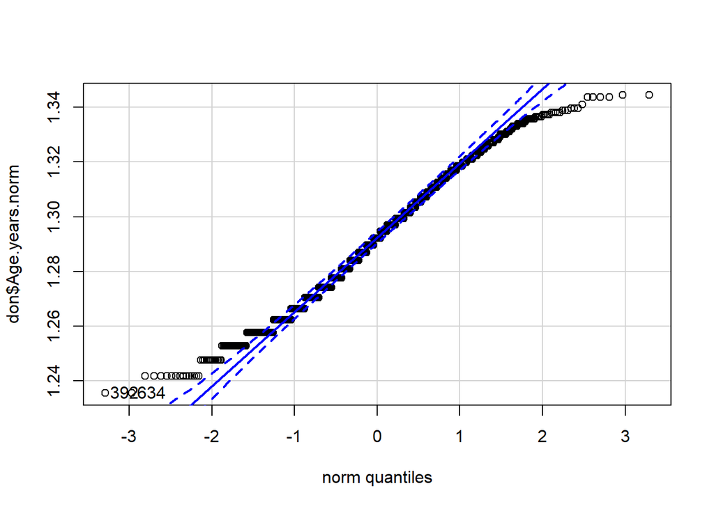

```
## [1] 392 634
```

```r
qqPlot(don$Age.years.norm)
```

```r
#on calcule le coefficient d'asym?trie
coefasym(don$Age.years)
```

```
## [1] 1.019208
```

```r
coefasym(don$Age.years.norm)
```

```
## [1] 0.02737609
```

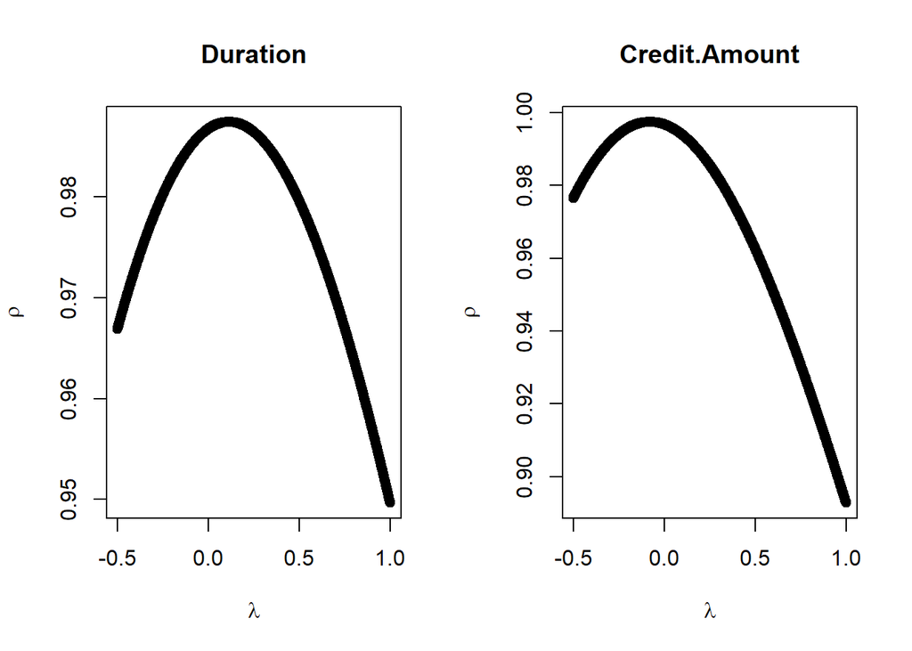

```r
par(mfrow=c(1,2))

# Duration
lambda.grid<-seq(-.5,1,1/1000)
res.cor<-myBoxCox(lambda.grid=lambda.grid,var=don$Duration)
plot(lambda.grid,res.cor,xlab=expression(lambda),ylab=expression(rho),main="Duration")
don$Duration.norm<-BoxCox(don$Duration,lambda = lambda.grid[which.max(res.cor)])

#Credit.Amount
lambda.grid<-seq(-.5,1,1/1000)
res.cor<-myBoxCox(lambda.grid=lambda.grid,var=don$Credit.Amount)
plot(lambda.grid,res.cor,xlab=expression(lambda),ylab=expression(rho),main="Credit.Amount")
```

```r
don$Credit.Amount.norm<-BoxCox(don$Credit.Amount,lambda = lambda.grid[which.max(res.cor)])

par(mfrow=c(2,2),mar=c(4,5, 3, 2) + 0.1)
qqPlot(don$Duration)
```

```
## [1] 678  30
```

```r
qqPlot(don$Duration.norm)
```

```
## [1] 678 235
```

```r
qqPlot(don$Credit.Amount)
```

```
## [1] 916  96
```

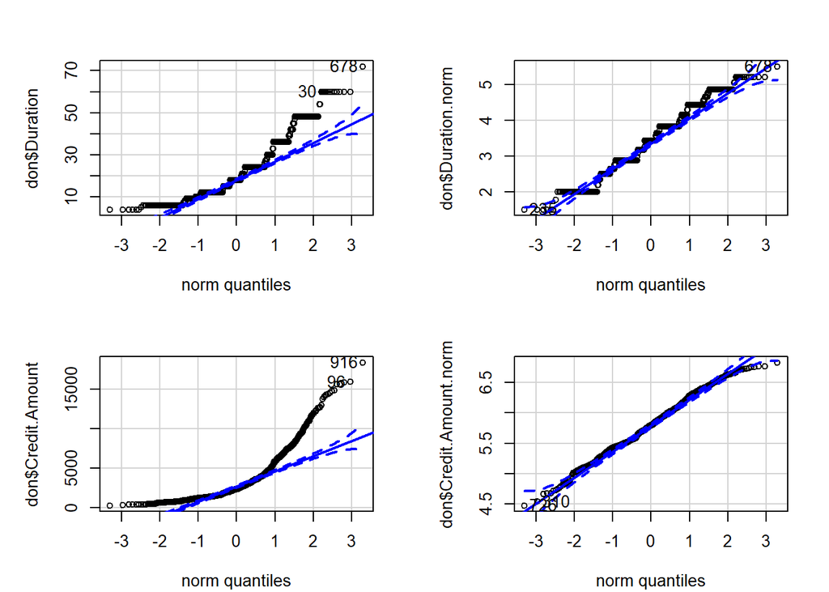

```
## [1] 726 310
```

```r
qqPlot(don$Credit.Amount.norm)
```

```r
sapply(don[,c("Credit.Amount","Credit.Amount.log","Credit.Amount.norm")],coefasym)
```

```
##      Credit.Amount  Credit.Amount.log Credit.Amount.norm
##         1.94670202         0.12909188        -0.02401317
```

Bien que la transformation logarithmique de la variable Credit.Amount soit satisfaisante, nous retiendrons plutôt celle de Box-Cox pour laquelle le coefficient d’asymétrie est plus proche de 0.

Remarquons qu’il existe d’autres façons de choisir le paramètre λ. En particulier, la fonction BoxCoxLambda du package DescTools propose une estimation par maximum de vraisemblance.

### 5.1.2 Variables qualitatives

Différentes méthodes sont souvent mises en défaut en présence de modalités rares comme les modèles de régression logistique, ou l’ACM qui est fortement influencée par ce type de données. Une stratégie de pré-traitement consiste alors à fusionner les modalités de faible effectif. L’étude exploratoire univariée effectuée en Section 4.1.2 a permis d’identifier des modalités rares sur les variables Status, History, Purpose, Savings account/bonds,Length.of.current.employment,Sex.Marital.Status, Other.installment.plans,Job, tandis que l’étude biavriée effectuée en Section 4.2.1.3 a permis d’identifier les modalités pour lesquelles la distribution de la variable réponse est similaire. A partir de là, on peut décider de fusionner les modalités suivantes :

```
History : noCredit.allPaid et thisBank.AllPaid
Purpose : Other, Education, Retraining
Purpose : DomesticAppliance, Repairs
Savings account/bonds : gt.1000 et 500.to.1000
Sex.Marital.Status : Male.Divorced.Seperated et Male.Single
Guarantor : CoApplicant et None
Other.installment.plans : Stores et None
Job : UnemployedUnskilled et UnskilledResident
```

On décide également d’enlever la variable Foreign.Worker dans la mesure où elle ne comporte que deux modalités, dont une rare et qu’elle ne semble pas très discriminante (cf Section 4.2.1.2).

```
## $History.new
##      [,1]
## [1,]  0.7
## [2,]  1.9
## [3,]  3.1
## [4,]  4.3
##
## $Purpose.new
##      [,1]
## [1,]  0.7
## [2,]  1.9
## [3,]  3.1
## [4,]  4.3
## [5,]  5.5
## [6,]  6.7
## [7,]  7.9
##
## $`Savings account/bonds.new`
##      [,1]
## [1,]  0.7
## [2,]  1.9
## [3,]  3.1
## [4,]  4.3
##
## $Sex.Marital.Status.new
##      [,1]
## [1,]  0.7
## [2,]  1.9
## [3,]  3.1
##
## $Guarantors.new
##      [,1]
## [1,]  0.7
## [2,]  1.9
##
## $Other.installment.plans.new
##      [,1]
## [1,]  0.7
## [2,]  1.9
##
## $Job.new
##      [,1]
## [1,]  0.7
## [2,]  1.9
## [3,]  3.1
```

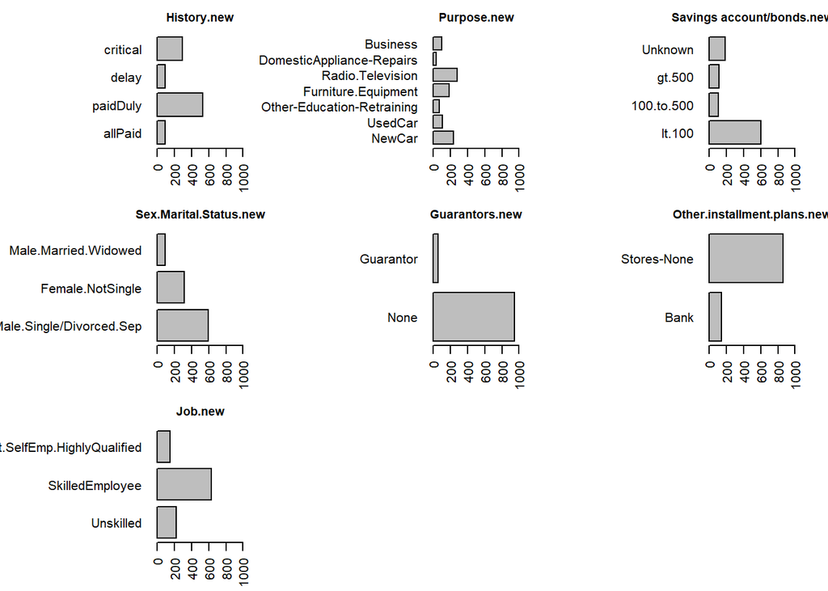

```r
# creation de nouvelles variables
don$History.new<-don$History
don$Purpose.new<-don$Purpose
don$`Savings account/bonds.new`<-don$`Savings account/bonds`
don$Sex.Marital.Status.new<-don$Sex.Marital.Status
don$Guarantors.new<-don$Guarantors
don$Other.installment.plans.new<-don$Other.installment.plans
don$Job.new<-don$Job

# fusion des modalit?s
levels(don$History.new)<-c("allPaid", "allPaid", "paidDuly", "delay",
                           "critical")
levels(don$Purpose.new)<-c("NewCar", "UsedCar", "Other-Education-Retraining", "Furniture.Equipment", "Radio.Television",
"DomesticAppliance-Repairs", "DomesticAppliance-Repairs", "Other-Education-Retraining", "Other-Education-Retraining", "Business")
levels(don$`Savings account/bonds.new`)<-c("lt.100",
                                           "100.to.500", "gt.500", "gt.500", "Unknown")
levels(don$Sex.Marital.Status.new)<-c("Male.Single/Divorced.Sep", "Female.NotSingle", "Male.Single/Divorced.Sep", "Male.Married.Widowed")
levels(don$Guarantors.new)<-c("None", "None", "Guarantor")
levels(don$Other.installment.plans.new)<-c("Bank","Stores-None", "Stores-None")
levels(don$Job.new)<-c("Unskilled", "Unskilled", "SkilledEmployee",
                       "Management.SelfEmp.HighlyQualified")

# suppression de la variables Foreign. Worker
don$Foreign.Worker<-NULL



par(mfrow=c(3,3),mar=c(3, 10, 2, 2) + 0.1)
mapply(don[,colnames(don)%in%paste0(names(var.factor),".new")],
       FUN=function(xx,name){barplot(table(xx),main=name,horiz = TRUE,las=2,xlim=c(0,1000),cex.main=.9)},
       name=colnames(don)[colnames(don)%in%paste0(names(var.factor),".new")])
```